# 期中大作业

小组成员：甘锦强、程虹、孔樱茹、王若卿

2023-05-05

# 任务分工

代码：甘锦强、程虹

文字分析、视频录制及剪辑：孔樱茹、王若卿

```r
knitr::opts_chunk$set(warning = FALSE, message = FALSE)
rm(list=ls())
# 加载包
pacman::p_load(ggplot2, dplyr, RColorBrewer, hrbrthemes, grDevices)

# 设定字体，特别注意里面有一个 enfont 和 cnfont 是我最常用的两个字体。
windowsFonts(
  enfont = windowsFont("Cascadia Code"),
  cnfont = windowsFont("Microsoft YaHei")
)
enfont = "enfont"
cnfont = "cnfont"

# 设定 ggplot2 绘图主题
theme_set(theme_ipsum(base_family = 'cnfont'))

# 这是设定 R 的基础绘图系统的绘图主题
library(basetheme)
pars <- basetheme("default")
pars$palette <- c("#2A363B", "#019875", "#99B898", "#FECEA8", "#FF847C", "#E84A5F", "#C0392B", "#96281B")
pars$bg  <- "white"
pars$fg  <- "gray20"
pars$col <- "gray20"
pars$col.main <- "black"
pars$col.axis <- "gray20"
pars$col.lab  <- "gray20"
pars$family   <-  "cnfont"
pars$lab      <-  c(10, 10, 7)
pars$cex.axis <-  0.8
pars$las      <-  0
pars$rect.border <- "black"
pars$rect.lwd    <- 4
basetheme(pars)

# 取消科学计数法的显示
options(scipen = 1)

# 设定 ggplot2 的默认调色板
options(
  ggplot2.continuous.colour = "viridis",
  ggplot2.continuous.fill = "viridis"
)
```

# 一、分析背景及目的

产品销售是企业盈利的一个重要环节，分析企业的历史销售数据能够帮助其更好的规划未来发展方向。本文以global-superstore，2011—2014年的销售明细为基础，利用数据可视化方式对公司4年的产品销售、市场分布以及产品利润等情况展开分析。通过研究商品的销售额、利润率等指标，对于公司产品的盈利状况进行判断，并基于此制定改进措施、为企业下一步的销售方案给出合适的推断和建议。

# 二、数据集来源

由公司内部数据库导出的订单数据文件global-superstore，其中包含订购日期、地区、销售额、利润等24个字段。

# 三、数据预处理

为方便进行后续数据可视化操作，我们团队对数据集作如下处理： 1、将‘market’与‘area’合并为‘marketarea’（如：“拉丁美洲”“南部”合并为“拉丁美洲南部”）。 2、将‘purchasedate’拆分为‘year’，‘month’，‘day’。 3、计算单价、单位利润、单位运费以及单位利润与单位运费的比率以便于后续分析。

```r
library(highcharter)
library(bbplot)
library(ggplot2)
library(dplyr)
library(gapminder)
library(gganimate)
library(ggalt)
library(tidyr)
library(tidyverse)
library(readxl)
library(sparkline)
library(formattable)
library(psych)
library(sf)
setwd("C:/Users/30296/Documents/大二下学期文档和资料/数据可视化")
orders <- read_excel("global-superstore(2).xlsx","订单")
# tidyr::unite  实现market与area合并为marketarea
orders1 <- orders %>%
  tidyr::unite(marketarea, market, area, sep='-')

# tidyr::separate 实现对purchasedate拆分为年月日
orders2 <-  orders1 %>%
  tidyr::separate(   col   = purchasedate,
                     into = c('year','month','day'),
                     sep  = '-'
  )

#单位运费和单位利润，以及两者的比值，来进一步调整销售计划
#单位运费和单位利润的比值rate1
orders3 <- orders2 %>%
  dplyr::mutate(unitprofit=profit/quantity ) %>%
  dplyr::mutate(unitprice=sales/quantity ) %>%
  dplyr::mutate(unitshipcost=shipcost/quantity ) %>%
  dplyr::mutate(rate1=unitshipcost/unitprofit )
orders4<-orders3%>%
  dplyr::mutate(cost=sales-profit )
```

# 四、产品具体情况分析

n表示样本大小，mean表示平均数，sd表示标准差，median表示中位数，min和max表示最小值和最大值，range表示极差，skew表示偏度，kurtosis表示峰度，se表示标准误差,mad表示中位数绝对偏差

```r
read_sf("C:/Users/30296/Documents/大二下学期文档和资料/数据可视化/world_high_resolution_mill.geo.json") -> wdmp
for(i in c ('2011','2012',"2013","2014")){assign(paste0('country_sales_',i),orders3 %>% dplyr::filter(year == i) %>%
  group_by(country,year) %>%
  summarise(sales=sum(sales)) %>%
  right_join(wdmp,by=c('country'="name")) %>%
  mutate(year=ifelse(is.na(year),i,year)))}

country_sales_4year <- country_sales_2011%>% rbind(country_sales_2012)%>% rbind(country_sales_2013)%>% rbind(country_sales_2014)

country_sales_total <- country_sales_4year %>% group_by(country) %>% summarise(sales=sum(sales)) %>% na.omit()
desc_sales <- country_sales_total$sales%>%psych::describe(quant = c(.25, .75)) %>%
  as_tibble() %>% gather() %>% dplyr::filter(row_number()!=1) %>% mutate(value=round(value,2))
desc_sales%>%
  formattable() %>% as.datatable(
    options = list(
      fnDrawCallback = htmlwidgets::JS(
        'function(){HTMLWidgets.staticRender();}'
      )
    )
  ) %>%
  spk_add_deps()
```

|  | key | value |
| --- | --- | --- |
| 1 | n | 113.00 |
| 2 | mean | 110037.75 |
| 3 | sd | 270715.17 |
| 4 | median | 25554.00 |
| 5 | trimmed | 46104.25 |
| 6 | mad | 31058.33 |
| 7 | min | 1621.93 |
| 8 | max | 2297200.86 |
| 9 | range | 2295578.93 |
| 10 | skew | 5.39 |

[output cut: 4 more lines]

## 4.1 销售额整体情况

### 4.1.1 计算不同年份每个国家销售额变化

```r
country_sales<-country_sales_4year%>%na.omit(sales) %>% group_nest(sales)
# desc_country_profit_4year <- country_profit_4year %>%psych::describe(quant = c(.25, .75)) %>%as_tibble()

country_sales %>% mutate(销售额=map_chr(data,function(x){spk_chr(x$sales)})) %>%
  mutate(平均数=round(map_dbl(data,function(x){mean(x$sales)}),2))%>%
  mutate(标准差=round(map_dbl(data,function(x){sd(x$sales)}),2))%>%
  mutate(最大值=round(map_dbl(data,function(x){max(x$sales)}),2))%>%
  mutate(最小值=round(map_dbl(data,function(x){min(x$sales)}),2))%>%
  arrange(desc(平均数))%>%
  select(-data)%>%
  formattable() %>% as.datatable(
    options = list(
      fnDrawCallback = htmlwidgets::JS(
        'function(){HTMLWidgets.staticRender();}'
      )
    )
  ) %>%
  spk_add_deps()
```

|  | country | 销售额 | 平均数 | 标准差 | 最大值 | 最小值 |
| --- | --- | --- | --- | --- | --- | --- |
| 1 | 美国 | {"x":{"values":[484247.4981,470532.509,608473.83,733947.0232],"options":{"height":20,"width":60},"width":60,"height":20},"evals":[],"jsHooks":[]} | 574300.22 | 123196.55 | 733947.02 | 470532.51 |
| 2 | 澳大利亚 | {"x":{"values":[137580.06,203950.842,268971.849,314733.102],"options":{"height":20,"width":60},"width":60,"height":20},"evals":[],"jsHooks":[]} | 231308.96 | 77269.34 | 314733.10 | 137580.06 |
| 3 | 法国 | {"x":{"values":[128194.515,192184.581,230114.6775,308437.3095],"options":{"height":20,"width":60},"width":60,"height":20},"evals":[],"jsHooks":[]} | 214732.77 | 75309.22 | 308437.31 | 128194.52 |
| 4 | 中国 | {"x":{"values":[155693.613,130224.873,195664.245,218979.294],"options":{"height":20,"width":60},"width":60,"height":20},"evals":[],"jsHooks":[]} | 175140.51 | 39743.59 | 218979.29 | 130224.87 |
| 5 | 德国 | {"x":{"values":[110006.781,154835.148,147461.0745,216537.027],"options":{"height":20,"width":60},"width":60,"height":20},"evals":[],"jsHooks":[]} | 157210.01 | 44153.22 | 216537.03 | 110006.78 |
| 6 | 墨西哥 | {"x":{"values":[111361.0482,156964.97,158784.9038,195479.69552],"options":{"height":20,"width":60},"width":60,"height":20},"evals":[],"jsHooks":[]} | 155647.65 | 34445.48 | 195479.70 | 111361.05 |
| 7 | 印度 | {"x":{"values":[91396.005,141493.035,151729.08,205031.985],"options":{"height":20,"width":60},"width":60,"height":20},"evals":[],"jsHooks":[]} | 147412.53 | 46588.72 | 205031.98 | 91396.01 |
| 8 | 英国 | {"x":{"values":[86188.551,124335.906,124046.802,194005.041],"options":{"height":20,"width":60},"width":60,"height":20},"evals":[],"jsHooks":[]} | 132144.08 | 44963.77 | 194005.04 | 86188.55 |
| 9 | 印度尼西亚 | {"x":{"values":[62253.4821,93407.4117,103891.8231,145334.781],"options":{"height":20,"width":60},"width":60,"height":20},"evals":[],"jsHooks":[]} | 101221.87 | 34315.59 | 145334.78 | 62253.48 |
| 10 | 巴西 | {"x":{"values":[57019.661,91609.38864,92705.256,119772.11332],"options":{"height":20,"width":60},"width":60,"height":20},"evals":[],"jsHooks":[]} | 90276.60 | 25714.35 | 119772.11 | 57019.66 |

[output cut: 126 more lines]

通过计算，得到每个国家在2011-2014年间所有销售额总和的趋势图，平均数，标准差，最大值和最小值。其中销售额最大的国家是美国，因此我们后面会重点分析美国的销售数据。而且标准差最大的也是美国，标准差大说明客户的消费价格差距大，有可能是由于当地的贫富差距大导致的。

### 4.1.2 市场销售额的主要市场分布的交互式饼状图

```r
area_sales<- orders %>%
  select(c('market','country',"sales")) %>%
  group_by(country,market) %>%
  summarise(sales=sum(sales))%>%
  group_by(market,country) %>%
  summarise(sales=sum(sales)) %>%
  arrange(desc(sales))%>%
  group_nest(market) %>%
  mutate(
    id = market,
    type = "column",
    data = map(data, mutate, name = country, y  = sales),
    data = map(data, list_parse))

area_sales_column <- orders %>%
  select(c('market',"sales")) %>%
  group_by(market) %>%
  summarise(sales=sum(sales)) %>%
  arrange(desc(sales))

area_sales_column%>% hchart(type="pie",hcaes(x=market,y=sales))%>%
  hc_tooltip(pointFormat = '销售额: <b>{point.sales}</b>') %>%
  hc_title(text = '主要市场的销售额占比',
           style = list(fontFamily = "SourceHanSerifSC-Medium")) %>%
  hc_add_theme(hc_theme_flat()) %>%
  hc_plotOptions(pie = list(
    allowPointSelect = TRUE,
    cursor = 'pointer',
    dataLabels = list(
      enabled = T,
      format = '<b>{point.name}</b>: {point.percentage:.1f} %'
    ),
    showInLegend = T
  ))
```

[interactive chart not shown]

此图展示了不同地区销售额占总销售额的比率关系，可得占比最大的地区为亚太地区，因此我们在后面会重点研究亚太地区的销售数据。

### 4.1.3 市场&国家销售额交互式钻取图

```r
area_sales<- orders %>%
  select(c('market','country',"sales")) %>%
  group_by(country,market) %>%
  summarise(sales=sum(sales))%>%
  group_by(market,country) %>%
  summarise(sales=sum(sales)) %>%
  arrange(desc(sales))%>%
  group_nest(market) %>%
  mutate(
    id = market,
    type = "column",
    data = map(data, mutate, name = country, y  = sales),
    data = map(data, list_parse))

area_sales_column <- orders %>%
  select(c('market',"sales")) %>%
  group_by(market) %>%
  summarise(sales=sum(sales)) %>%
  arrange(desc(sales))
x <- c("销售额")
y <- c("{point.sales}")

tt <- tooltip_table(x, y)

hchart(
  area_sales_column,
  type="column",
  hcaes(x = market, y = sales, name = market, drilldown = market),
  name = "Sales",
  colorByPoint = TRUE
) %>%
  hc_drilldown(
    allowPointDrilldown = TRUE,
    series = list_parse(area_sales)
  ) %>%
  hc_tooltip(
    pointFormat = tt, # "{point.name} {point.pop}"
    useHTML = TRUE,
    valueDecimals = 0
  ) %>%
  hc_yAxis(
    title = list(text = "销售额"),
    type = "logarithmic",
    minorTickInterval = 'auto'
  ) %>%
  hc_xAxis(
    title = ""
  ) %>%
  hc_add_theme(hc_theme_flat(chart = list(
    style = list(fontFamily = "Source Han Serif")

  )))
```

[interactive chart not shown]

这张图更加直观地展示了从亚太地区到加拿大的不同地区销售额的大小以及大小关系， 还有他们内部不同国家间销售额的大小以及大小关系。其中亚太地区的销售额最大，亚太地区的不同国家中，澳大利亚的销售额最大，蒙古的销售额最小。

### 4.1.4 产品销售额分布的世界地图

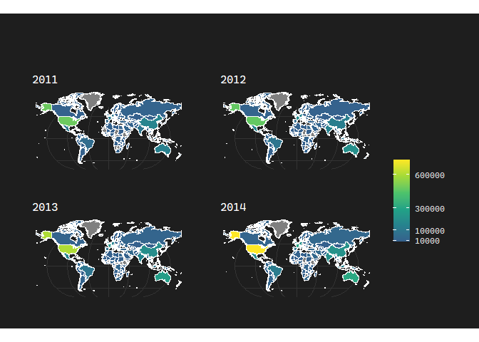

```r
theme_set(theme_bw())
wciso <- rnaturalearthdata::countries50 %>%
  as_tibble()
for(i in c ('2011','2012',"2013","2014")){assign(paste0('country_sales_',i),orders3 %>% dplyr::filter(year == i) %>%
  group_by(country,year) %>%
  summarise(sales=sum(sales)) %>%
  right_join(wdmp,by=c('country'="name")) %>%
  mutate(year=ifelse(is.na(year),i,year)))}

country_sales_4year <- country_sales_2011%>% rbind(country_sales_2012)%>% rbind(country_sales_2013)%>% rbind(country_sales_2014)
title=ggtitle(paste("全球销售额年分布情况"))
country_sales_png <- country_sales_4year%>% ggplot()+

  geom_sf(aes(fill=sales,geometry=geometry),size=1,color="white") +
  theme_modern_rc(base_family = enfont,
                  caption_family = enfont,
                  subtitle_family = enfont,
                  )+
  coord_sf(crs = "+proj=eck4")+
  scale_fill_viridis_c(option = "viridis",name = "销售额",na.value="grey50",begin=0.3,end=1,breaks = c(10000,100000,300000,600000))+
    facet_wrap(~year,ncol=2)+
    theme(strip.text = element_text(color = "white"),axis.text.x = element_blank())+
  title
ggsave("country_sales_4years.png", width = 12, height = 6, dpi = 1000)
country_sales_png
```

### 4.1.5 各个市场总销售额的时间序列图

其中亚太地区的销售量在四年间都是第一

```r
time_orders<-orders %>% dplyr::mutate( year = lubridate::year(purchasedate),
) %>%
  group_by(market,year) %>%
  dplyr::summarise(totalsales = sum(sales))
time_orders%>%
  pull(market) -> marketlist

time_orders %>%
  dplyr::filter(market %in% marketlist) %>%
  hchart(type = "line", hcaes(x = year, y = totalsales, group = market)) %>%
  hc_title(text = "各个市场总销售额的时间序列图") %>%
  hc_add_theme(hc_theme_flat(chart = list(
    style = list(fontFamily = "Source Han Serif")
  ))) %>%
  hc_credits(enabled = T) %>%
  hc_legend(align = 'left',
            floating = TRUE,
            layout = 'vertical',
            x = 80, y =-300)
```

[interactive chart not shown]

### 4.1.6 市场——产品关于数量分布的桑基图

为观察这四年总体的产品销售流向，我们制作了桑基图和整体趋势图。

[figure not shown]

```r
library(ggalluvial)
library(networkD3)
s1<-orders[,c(16)]
s2<-orders[,c(13)]
s3<-orders[,c(20)]
s<-cbind(s1,s2,s3)
s11<-s%>% dplyr::filter(type == '办公用品') %>%
  group_by(market) %>%
  dplyr::summarise(totalquantity = sum(quantity))%>%dplyr::mutate(type="办公用品")
s12<-s%>% dplyr::filter(type == '家具') %>%
  group_by(market) %>%
  dplyr::summarise(totalquantity = sum(quantity))%>%dplyr::mutate(type="家具")
s13<-s%>% dplyr::filter(type == '技术') %>%
  group_by(market) %>%
  dplyr::summarise(totalquantity = sum(quantity))%>%dplyr::mutate(type="技术")
ss<-rbind(s11,s12,s13)
colnames(ss) <- c("商品类别", "value", "variable")
ggplot(ss,
       aes(axis1=商品类别, axis2=variable, y=value)) +
  scale_x_discrete(limits = c("商品类别","市场"),expand = c(0.05,0.05)) +
  geom_alluvium(aes(fill=value)) +
  geom_stratum(width=0.4,fill="#E2AC76",color="black") +
  geom_text(stat = "stratum", aes(label = after_stat(stratum)),size=4,color="black")+
  labs(title="市场——产品分布图")
```

```r
ggsave('market_quantity.png')
```

从桑基图中可以看出，办公用品类产品的出售数量很大，家具和技术类的数量较少。说明技术类和家具类产品属于固定资产的较多，消费者一般会采用一次性购置的方式，而办公用品易损坏，消费者一般都会一次购置一定数量或是多次购置。

### 4.1.7 不同市场三种产品销售额的时间变化

所有的地区的销售额都呈上升趋势，其中办公产品类别欧盟销售量超过亚太地区成为第一

[figure not shown]

```r
orders %>% dplyr::mutate( year = lubridate::year(purchasedate),
) %>%
  group_by(type,year,market) %>%
  dplyr::summarise(totalsales = sum(sales)) %>%
  ggplot(., aes(x = year, y = totalsales, colour = factor(market))) +
  geom_line() +
  scale_x_continuous(breaks=2011:2014) +
  facet_grid( type ~ .)+
  theme_bw()+
  theme(legend.position = "top",
        legend.justification = "left",text=element_text(size=10,family = cnfont),plot.title = element_text(hjust=0.0),legend.title = element_blank())+
  guides(fill = guide_legend(nrow = 1,ncol=4, byrow = T,reverse=TRUE))+
  labs(title="各市场三种产品销量变化趋势")
```

```r
ggsave('market_product_sales_4year.png')
```

### 4.1.8 各个市场不同类别的细分市场的销售数量

```r
orders %>% group_by(market,type,segment) %>%
  summarise(totalqty = sum(quantity))
```

```
## # A tibble: 63 × 4
## # Groups:   market, type [21]
##    market   type     segment    totalqty
##    <chr>    <chr>    <chr>         <dbl>
##  1 EMEA     办公用品 公司           2238
##  2 EMEA     办公用品 家庭办公室     1414
##  3 EMEA     办公用品 消费者         3826
##  4 EMEA     家具     公司            585
##  5 EMEA     家具     家庭办公室      384
##  6 EMEA     家具     消费者          811
##  7 EMEA     技术     公司            692
##  8 EMEA     技术     家庭办公室      333
##  9 EMEA     技术     消费者         1234
## 10 亚太地区 办公用品 公司           6765
## # … with 53 more rows
```

[figure not shown]

```r
y_axis_formatter = function(x){
  return(paste(x/1000,'K',sep=""))
}

ggplot(orders, aes(x = segment, y = quantity)) +
  geom_bar(stat='identity') +
  facet_grid(type ~ market) +
  scale_y_continuous(labels=y_axis_formatter) +
  xlab("细分市场") +
  ylab("数量") +
  theme(axis.text.y = element_text(angle=45),plot.margin = margin(1.5,1,1,1, unit = "cm"))+
  coord_flip() +
  labs(title="各市场三种产品销量")
```

```r
ggsave('market_product_sales.png')
```

从上图中，我们可以看出，不同地区各种type的物品的消费群体分布，其中普通消费者的购买数更多，其次是以公司为单位的购买者，数量最少的是家庭办公室。办公物品比家具和技术的销售量更高。

### 4.1.9 销售量最大的亚太地区销售量前十国分布矩形树图

```r
tree_data <- orders %>% dplyr::filter(market == "亚太地区") %>%
  group_by(country) %>%
  dplyr::summarise(totalsales = sum(sales)) %>%top_n(10, totalsales)
colnames(tree_data) <- c('country','totalsales')
highchart() %>%
  hc_colorAxis(     maxColor = "#0043AE")%>%
  hc_title(text = "亚太地区销售量前十国分布矩形树图")%>%
  hc_add_series(data = tree_data,type = "treemap",hcaes(name = country,value = totalsales,colorValue =value),layoutAlgorithm = "squarified") %>%
  hc_add_theme(hc_theme_flat(chart = list(
    style = list(fontFamily = "Source Han Serif")
  ))) %>%
  hc_credits(enabled = T)
```

[interactive chart not shown]

从该矩形树图中可以看出，其中销售量前十的地区从大到小分别是澳大利亚，中国，印度，印度尼西亚，菲律宾，新西兰，日本，孟加拉国，泰国和越南。

**接下来我们将对这些亚太地区销售量前十的产品销售分布进行分析。**

### 4.1.10 亚太地区销售量前十的产品销售分布玫瑰图

```r
library(data.table)
rosedata1 <- orders %>% dplyr::filter(country == "澳大利亚") %>%
  group_by(type) %>%
  dplyr::summarise(totalsales = sum(sales))%>%dplyr::mutate(country="澳大利亚")
#rosedata_1 <- data.table(melt(rosedata1,"country"))
rosedata2 <- orders %>% dplyr::filter(country == "中国") %>%
  group_by(type) %>%
  dplyr::summarise(totalsales = sum(sales))%>%dplyr::mutate(country="中国")
rosedata3 <- orders %>% dplyr::filter(country == "印度") %>%
  group_by(type) %>%
  dplyr::summarise(totalsales = sum(sales))%>%dplyr::mutate(country="印度")
rosedata4 <- orders %>% dplyr::filter(country == "印度尼西亚") %>%
  group_by(type) %>%
  dplyr::summarise(totalsales = sum(sales))%>%dplyr::mutate(country="印度尼西亚")
rosedata5 <- orders %>% dplyr::filter(country == "菲律宾") %>%
  group_by(type) %>%
  dplyr::summarise(totalsales = sum(sales))%>%dplyr::mutate(country="菲律宾")
rosedata6 <- orders %>% dplyr::filter(country == "新西兰") %>%
  group_by(type) %>%
  dplyr::summarise(totalsales = sum(sales))%>%dplyr::mutate(country="新西兰")
rosedata7 <- orders %>% dplyr::filter(country == "日本") %>%
  group_by(type) %>%
  dplyr::summarise(totalsales = sum(sales))%>%dplyr::mutate(country="日本")
rosedata8 <- orders %>% dplyr::filter(country == "孟加拉国") %>%
  group_by(type) %>%
  dplyr::summarise(totalsales = sum(sales))%>%dplyr::mutate(country="孟加拉国")
rosedata9 <- orders %>% dplyr::filter(country == "泰国") %>%
  group_by(type) %>%
  dplyr::summarise(totalsales = sum(sales))%>%dplyr::mutate(country="泰国")
rosedata10 <- orders %>% dplyr::filter(country == "越南") %>%
  group_by(type) %>%
  dplyr::summarise(totalsales = sum(sales))%>%dplyr::mutate(country="越南")
rose_data<-rbind(rosedata1,rosedata2,rosedata3,rosedata4,rosedata5,rosedata6,rosedata7,rosedata8,rosedata9,rosedata10)
sumsales1<-rose_data%>%dplyr::summarise(sumsales1 = sum(totalsales))
rose_data<-rose_data%>%dplyr::mutate(sumsales="3297672")
rose_data[,c(2)] <- as.numeric(unlist(rose_data[,c(2)]))
rose_data[,c(4)] <- as.numeric(unlist(rose_data[,c(4)]))
rose_data<-rose_data%>%
  dplyr::mutate(rate=totalsales/sumsales)
rose_data=rose_data[,-4]

#orders3 <- orders2 %>%
 # dplyr::mutate(unitprofit=profit/quantity )


colnames(rose_data) <- c('variable','value','country','rate')
#rose_data[,rate:= round(ifelse(value>= 0,value,0)/ sum(ifelse(value>= 0,value,0))*100,2)]
highchart() %>%
  #polar设置极坐标
  hc_chart(polar = TRUE,type = "column") %>%
  hc_title(text = "亚太地区销售量前十的产品销售分布",x=-50) %>%
  #设置图形大小
  hc_pane(size = "85%") %>%
  #设置图例位置
  hc_legend(align = "right",verticalAlign = "top",y = 100,layout = "vertical") %>%
  hc_yAxis(title = list(text = "占比 (%)",
                        #设置轴标题的位置
                        x= 0,
                        y=-30),
           #颠倒堆积的顺序
           reversedStacks = FALSE) %>%
  hc_xAxis(categories = unique(rose_data$country))%>%
  hc_tooltip(
    #提示框的值显示百分比
    valueSuffix = "%") %>%
  hc_plotOptions(series = list(stacking = "normal",pointPlacement= "on",groupPadding = 0,shadow = FALSE))%>%
  hc_add_series(data=rose_data,type = "column",hcaes(y=rate,group = variable)) %>%
  hc_add_theme(hc_theme_flat(chart = list(
    style = list(fontFamily = "Source Han Serif")
  )))
```

[interactive chart not shown]

从玫瑰图中可以看出，亚太地区前十国家销售最多的type是技术，其次是家具，最后是办公用品。说明该地区消费者对于技术类产品倾斜度高。与前面的图片里亚太地区总体办公用品销售量最高的事实相反，因此我们可以猜测这是因为国家越发达对于技术的需求量越大。

### 4.1.11 分析销售量最大的国家——美国各种产品的占比

```r
data <- orders %>% dplyr::filter(country == '美国') %>%
  group_by(subtype) %>%
  dplyr::summarise(totalsales = sum(sales)) %>%
  arrange(desc(totalsales))
#data$totalsales = with(data,reorder(subtype,totalsales))
#sumsales<-data %>% dplyr::summarise(sumsales = sum(totalsales))
#rate<-data%>%
  #group_by(subtype) %>%
 # dplyr::mutate(rate=totalsales/sumsales)
colnames(data) <- c('name','y')
highchart() %>%
  hc_chart(type = "pie") %>%
  hc_add_series(data = data,
                innerSize = '60%',
                colorByPoint = TRUE) %>%
  hc_tooltip(pointFormat = '{series.name}: <b>{point.percentage:.1f}%</b>') %>%
  hc_title(text = '美国各种产品的占比',
           style = list(fontFamily = "SourceHanSerifSC-Medium")) %>%
  hc_subtitle(style = list(fontFamily = "SourceHanSerifSC-Medium")) %>%
  hc_add_theme(hc_theme_flat()) %>%
  hc_plotOptions(pie = list(
    allowPointSelect = TRUE,
    cursor = 'pointer',
    dataLabels = list(
      enabled = T,
      format = '<b>{point.name}</b>: {point.percentage:.1f} %'
    ),
    showInLegend = T
  ))
```

[interactive chart not shown]

美国是所有国家中销售量最大的国家，因此我们团队对该国的产品消费种类进行了也重点分析。此图表述了各种subtype的销售占比。其中销售占比最大的是电话，最小的是系固件。

**各种细分产品在不同市场销售分布钻取图**

```r
subtype_per<- orders %>%
  select(c('subtype','market',"sales")) %>%
  group_by(market,subtype) %>%
  summarise(sales=sum(sales))%>%
  group_by(subtype,market) %>%
  summarise(sales=sum(sales)) %>%
  group_by(market)%>%
  mutate(sales=sales/sum(sales))%>%
  group_by(subtype) %>%
  arrange(desc(sales)) %>%
  group_nest(subtype) %>%
  mutate(
    id = subtype,
    type = "column",
    data = map(data, mutate, name = market, y  = sales),
    data = map(data, list_parse))

area_sales_column <- orders %>%
  select(c('subtype',"sales")) %>%
  group_by(subtype) %>%
  summarise(sales=sum(sales)) %>%
  arrange(desc(sales))

x <- c("销售额/销售额在地区占比")
y <- c("{point.sales}")

tt <- tooltip_table(x, y)

hchart(
  area_sales_column,
  type="column",
  hcaes(x = subtype, y = sales, name = subtype, drilldown = subtype),
  name = "Sales",
  colorByPoint = TRUE
) %>%
  hc_drilldown(
    allowPointDrilldown = TRUE,
    series = list_parse(subtype_per)
  ) %>%
  hc_tooltip(
    pointFormat = tt, # "{point.name} {point.pop}"
    useHTML = TRUE,
    valueDecimals = 0
  ) %>%
  hc_yAxis(
    title = list(text = "销售额/销售额在地区占"),
    type = "logarithmic",
    minorTickInterval = 'auto'
  ) %>%
  hc_xAxis(
    title = ""
  ) %>%
  hc_add_theme(hc_theme_flat(chart = list(
    style = list(fontFamily = "Source Han Serif")

  )))
```

[interactive chart not shown]

各种细分产品在各个地区的销售额，可见电话的销售额最大，其中它在美国的销售额最大。

## 4.2 利润的整体情况

```r
read_sf("C:/Users/30296/Documents/大二下学期文档和资料/数据可视化/world_high_resolution_mill.geo.json") -> wdmp
for(i in c ('2011','2012',"2013","2014")){assign(paste0('country_profit_',i),orders3 %>% dplyr::filter(year == i) %>%
  group_by(country,year) %>%
  summarise(profit=sum(profit)) %>%
  right_join(wdmp,by=c('country'="name")) %>%
  mutate(year=ifelse(is.na(year),i,year)))}

country_profit_4year <- country_profit_2011%>% rbind(country_profit_2012)%>% rbind(country_profit_2013)%>% rbind(country_profit_2014)

country_profit_total <- country_profit_4year %>% group_by(country) %>% summarise(profit=sum(profit)) %>% na.omit()
desc_profit <- country_profit_total$profit%>%psych::describe(quant = c(.25, .75)) %>%
  as_tibble() %>% gather() %>% dplyr::filter(row_number()!=1) %>% mutate(value=round(value,2))
desc_profit%>%
  formattable() %>% as.datatable(
    options = list(
      fnDrawCallback = htmlwidgets::JS(
        'function(){HTMLWidgets.staticRender();}'
      )
    )
  ) %>%
  spk_add_deps()
```

|  | key | value |
| --- | --- | --- |
| 1 | n | 113.00 |
| 2 | mean | 12882.59 |
| 3 | sd | 42154.63 |
| 4 | median | 3296.58 |
| 5 | trimmed | 6434.93 |
| 6 | mad | 8613.79 |
| 7 | min | -98447.23 |
| 8 | max | 286397.02 |
| 9 | range | 384844.25 |
| 10 | skew | 3.10 |

[output cut: 4 more lines]

### 4.2.1 计算不同年份每个国家利润额变化

```r
for(i in c ('2011','2012',"2013","2014")){assign(paste0('country_sales_',i),orders3 %>% dplyr::filter(year == i) %>%
  group_by(country,year) %>%
  summarise(sales=sum(sales)) %>%
  right_join(wdmp,by=c('country'="name")) %>%
  mutate(year=ifelse(is.na(year),i,year)))}

country_sales_4year <- country_sales_2011%>% rbind(country_sales_2012)%>% rbind(country_sales_2013)%>% rbind(country_sales_2014)


country_profit<-country_profit_4year%>%
  full_join(country_sales_4year) %>%
  na.omit(profit) %>%
  group_nest(country)
# desc_country_profit_4year <- country_profit_4year %>%psych::describe(quant = c(.25, .75)) %>%as_tibble()

country_profit %>%
  mutate(利润总额=round(map_dbl(data,function(x){sum(x$profit)}),2))%>%
  mutate(利润率=paste0(round(map_dbl(data,function(x){sum(x$profit)/sum(x$sales)}),2),"%"))%>%
  mutate(年利润额=map_chr(data,function(x){spk_chr(x$profit)})) %>%
  mutate(平均数=round(map_dbl(data,function(x){mean(x$profit)}),2))%>%
  mutate(标准差=round(map_dbl(data,function(x){sd(x$profit)}),2))%>%
  mutate(最大值=round(map_dbl(data,function(x){max(x$profit)}),2))%>%
  mutate(最小值=round(map_dbl(data,function(x){min(x$profit)}),2))%>%
  arrange(desc(利润总额))%>%
  select(-data)%>%
  formattable() %>% as.datatable(
    options = list(
      fnDrawCallback = htmlwidgets::JS(
        'function(){HTMLWidgets.staticRender();}'
      )
    )
  ) %>%
  spk_add_deps()
```

|  | country | 利润总额 | 利润率 | 年利润额 | 平均数 | 标准差 | 最大值 | 最小值 |
| --- | --- | --- | --- | --- | --- | --- | --- | --- |
| 1 | 美国 | 286397.02 | 0.12% | {"x":{"values":[49543.9741,61618.6037,81726.9308,93507.5131],"options":{"height":20,"width":60},"width":60,"height":20},"evals":[],"jsHooks":[]} | 71599.26 | 19736.52 | 93507.51 | 49543.97 |
| 2 | 中国 | 150683.08 | 0.22% | {"x":{"values":[33181.383,26233.773,44473.935,46793.994],"options":{"height":20,"width":60},"width":60,"height":20},"evals":[],"jsHooks":[]} | 37670.77 | 9669.12 | 46793.99 | 26233.77 |
| 3 | 印度 | 129071.84 | 0.22% | {"x":{"values":[19928.505,27438.795,32896.86,48807.675],"options":{"height":20,"width":60},"width":60,"height":20},"evals":[],"jsHooks":[]} | 32267.96 | 12241.20 | 48807.68 | 19928.51 |
| 4 | 英国 | 111900.15 | 0.21% | {"x":{"values":[20080.221,27365.886,27698.442,36755.601],"options":{"height":20,"width":60},"width":60,"height":20},"evals":[],"jsHooks":[]} | 27975.04 | 6828.23 | 36755.60 | 20080.22 |
| 5 | 法国 | 109029.00 | 0.13% | {"x":{"values":[18435.675,23034.741,32416.4775,35142.1095],"options":{"height":20,"width":60},"width":60,"height":20},"evals":[],"jsHooks":[]} | 27257.25 | 7840.88 | 35142.11 | 18435.68 |
| 6 | 德国 | 107322.82 | 0.17% | {"x":{"values":[19554.861,24867.438,26944.4745,35956.047],"options":{"height":20,"width":60},"width":60,"height":20},"evals":[],"jsHooks":[]} | 26830.71 | 6833.18 | 35956.05 | 19554.86 |
| 7 | 澳大利亚 | 103907.43 | 0.11% | {"x":{"values":[17516.73,25528.722,28831.779,32030.202],"options":{"height":20,"width":60},"width":60,"height":20},"evals":[],"jsHooks":[]} | 25976.86 | 6233.46 | 32030.20 | 17516.73 |
| 8 | 墨西哥 | 102818.10 | 0.17% | {"x":{"values":[18521.7482,24955.27,28010.2638,31330.81552],"options":{"height":20,"width":60},"width":60,"height":20},"evals":[],"jsHooks":[]} | 25704.52 | 5450.54 | 31330.82 | 18521.75 |
| 9 | 西班牙 | 54390.12 | 0.19% | {"x":{"values":[8644.845,8953.461,16198.005,20593.809],"options":{"height":20,"width":60},"width":60,"height":20},"evals":[],"jsHooks":[]} | 13597.53 | 5825.43 | 20593.81 | 8644.84 |
| 10 | 萨尔瓦多 | 42023.24 | 0.24% | {"x":{"values":[9168.00024,5781.423,13165.81124,13908.00872],"options":{"height":20,"width":60},"width":60,"height":20},"evals":[],"jsHooks":[]} | 10505.81 | 3775.36 | 13908.01 | 5781.42 |

[output cut: 126 more lines]

通过计算，得到每个国家在2011-2014年间所有利润总和的趋势图，平均数，标准差，最大值和最小值。其中美国的利润最大。

### 4.2.2主要市场的利润占比

此图展示了不同地区利润占总销售额的比率关系，可得占比最大的地区为亚太地区

```r
area_profit<- orders %>%
  select(c('market','country',"profit")) %>%
  group_by(country,market) %>%
  summarise(profit=sum(profit))%>%
  group_by(market,country) %>%
  summarise(profit=sum(profit)) %>%
  arrange(desc(profit))%>%
  group_nest(market) %>%
  mutate(
    id = market,
    type = "column",
    data = map(data, mutate, name = country, y  = profit),
    data = map(data, list_parse))

area_profit_column <- orders %>%
  select(c('market',"profit")) %>%
  group_by(market) %>%
  summarise(profit=sum(profit)) %>%
  arrange(desc(profit))

area_profit_column%>% hchart(type="pie",hcaes(x=market,y=profit))%>%
  hc_tooltip(pointFormat = '销售额: <b>{point.profit}</b>') %>%
  hc_title(text = '主要市场的利润占比',
           style = list(fontFamily = "SourceHanSerifSC-Medium")) %>%
  hc_add_theme(hc_theme_flat()) %>%
  hc_plotOptions(pie = list(
    allowPointSelect = TRUE,
    cursor = 'pointer',
    dataLabels = list(
      enabled = T,
      format = '<b>{point.name}</b>: {point.percentage:.1f} %'
    ),
    showInLegend = T
  ))
```

[interactive chart not shown]

### 4.2.3 市场&国家利润额交互式钻取图

这张图更加直观地展示了从亚太地区到加拿大的不同地区利润的大小以及大小关系， 还有他们内部不同国家间利润的大小以及大小关系。

```r
x <- c("利润额")
y <- c("{point.profit}")

tt <- tooltip_table(x, y)

hchart(
  area_profit_column,
  type="column",
  hcaes(x = market, y = profit, name = market, drilldown = market),
  name = "Sales",
  colorByPoint = TRUE
) %>%
  hc_drilldown(
    allowPointDrilldown = TRUE,
    series = list_parse(area_profit)
  ) %>%
  hc_tooltip(
    pointFormat = tt, # "{point.name} {point.pop}"
    useHTML = TRUE,
    valueDecimals = 0
  ) %>%
  hc_yAxis(
    title = list(text = "利润额"),
    type = "logarithmic",
    minorTickInterval = 'auto'
  ) %>%
  hc_xAxis(
    title = ""
  ) %>%
  hc_add_theme(hc_theme_flat(chart = list(
    style = list(fontFamily = "Source Han Serif")

  )))
```

[interactive chart not shown]

### 4.2.4 各种细分产品的利润额和在各地区和利润率

```r
subtype_prrate<- orders %>%
  select(c('subtype','market',"sales","profit")) %>%
  group_by(subtype,market) %>%
  summarise(sales=sum(sales),profit=sum(profit)) %>%
  group_by(market)%>%
  mutate(pr_rate=profit/sales)%>%
  group_by(subtype) %>%
  arrange(desc(pr_rate)) %>%
  group_nest(subtype) %>%
  mutate(
    id = subtype,
    type = "column",
    data = map(data, mutate, name = market, y  = pr_rate),
    data = map(data, list_parse))

area_profit_column <- orders %>%
  select(c('subtype',"profit")) %>%
  group_by(subtype) %>%
  summarise(profit=sum(profit)) %>%
  arrange(desc(profit))

x <- c("利润额/利润额在地区占比")
y <- c("{point.pr_rate}")

tt <- tooltip_table(x, y)

hchart(
  area_profit_column,
  type="column",
  hcaes(x = subtype, y = profit, name = subtype, drilldown = subtype),
  name = "profit",
  colorByPoint = TRUE
) %>%
  hc_drilldown(
    allowPointDrilldown = TRUE,
    series = list_parse(subtype_prrate)
  ) %>%
  hc_tooltip(
    pointFormat = tt, # "{point.name} {point.pop}"
    useHTML = TRUE,
    valueDecimals = 0
  ) %>%
  hc_yAxis(
    title = list(text = "利润额/利润额在地区占比"),
    type = "logarithmic",
    minorTickInterval = 'auto'
  ) %>%
  hc_xAxis(
    title = ""
  ) %>%
  hc_add_theme(hc_theme_flat(chart = list(
    style = list(fontFamily = "Source Han Serif")

  )))
```

[interactive chart not shown]

各种细分产品在各个地区的利润，可见复印机的利润最大，其中它在美国的利润最大。这与上文电话销售额最大的情况有些出入。

## 4.3 对比销售额和利润，结合运输费用、成本和折扣来分析有些部分商品销售额高而利润低或者是有些特殊商品销售额高利润高的原因（例如：成本，运费，定价）

### 4.3.1 宏观角度——整体销售额及利润额占比

在对于市场情况、销售额以及利润有了初步分析后，我们将各种因素进行综合比较分析。首先是从宏观角度分析，各市场的销售额及利润额占比如下图，其中内圈层是利润率，外圈层是销售额。由图可以看出各地区利润额的占比基本上与销售额趋同，只有EMEA和拉丁美洲两个地区利润额占比与销售额占比差距在2%以上。为探究原因，我们对每种类型的产品制作了总成本、平均运输成本以及运输成本率（总运输成本/销售额）的表格。

**销售额与利润额饼图**

```r
area_sales_column <- orders %>%
  select(c('market',"sales")) %>%
  group_by(market) %>%
  summarise(sales=sum(sales)) %>%
  arrange(desc(sales))
area_profit_column <- orders %>%
  select(c('market',"profit")) %>%
  group_by(market) %>%
  summarise(profit=sum(profit)) %>%
  arrange(desc(profit))
area_prosales<-area_profit_column%>%full_join(area_sales_column,by='market')%>%mutate(profit=round((profit/sum(profit)),2),sales=round(sales/sum(sales),2))

highchart() %>%
  hc_add_series(area_prosales,type = "pie",hcaes(name = market, y = sales),name = "销售份额",
                #控制环的粗细
                innerSize = "80%",align='center')%>%
   hc_add_series(area_prosales,type = "pie",hcaes(name = market, y = profit),name = "利润份额",
                #控制环的粗细
                size = "50%",innerSize='70%',align='center')%>%

  hc_tooltip(pointFormat = '{series.name}: <b>{point.percentage:.1f}%</b>') %>%
  hc_title(text = '各市场销售额及利润额占比',
           style = list(fontFamily = "SourceHanSerifSC-Medium")) %>%
  hc_add_theme(hc_theme_flat()) %>%
  hc_plotOptions(pie = list(
    allowPointSelect = TRUE,
    cursor = 'pointer',
    dataLabels = list(
      enabled = T,
      format = '<b>{point.market}</b>: {point.percentage:.1f} %'
    ),
    showInLegend = T
  ))
```

[interactive chart not shown]

**产品类型分布情况表**

```r
type_prrate_2<- orders %>%
  select(c('type','market',"sales","profit","shipcost")) %>%
  group_by(type,market) %>%
  summarise(sales=sum(sales),profit=sum(profit),total_cost=sum(shipcost),avcost=round(mean(shipcost),2)) %>%
  group_by(market)%>%
  mutate(cost_rate=round((total_cost/sales),4),pr_rate=round((profit/sales),4))%>%
  group_by(type) %>%
  arrange(desc(pr_rate))

type_prrate_2%>%
  reactable::reactable(pagination = TRUE,
                       groupBy = 'type',
                       compact = T,
                       searchable = TRUE,
striped = TRUE,
highlight = TRUE,
bordered = TRUE)
```

| type | market | sales | profit | total_cost | avcost | cost_rate | pr_rate |
| --- | --- | --- | --- | --- | --- | --- | --- |
| 技术 | 加拿大 | 26298.81 | 7246.62 | 2822.35 | 43.42 | 0.1073 | 0.2755 |
| 办公用品 | 加拿大 | 30034.08 | 7957.53 | 3388.53 | 12.23 | 0.1128 | 0.265 |
| 家具 | 加拿大 | 10595.28 | 2613.24 | 1194.75 | 28.45 | 0.1128 | 0.2466 |
| 技术 | 美国 | 836154.033 | 145454.9481 | 94634.69 | 51.24 | 0.1132 | 0.174 |
| 办公用品 | 美国 | 719047.032 | 122490.8008 | 78727.88 | 13.06 | 0.1095 | 0.1704 |
| 办公用品 | 欧盟 | 1046307.024 | 159706.944 | 114358.54 | 17.36 | 0.1093 | 0.1526 |
| 技术 | 亚太地区 | 1357490.226 | 204593.856 | 150718.96 | 62.9 | 0.111 | 0.1507 |
| 办公用品 | 拉丁美洲 | 563920.732 | 79459.072 | 61439.695 | 10.48 | 0.109 | 0.1409 |
| 技术 | 非洲 | 322367.043 | 44129.493 | 36634.49 | 40.21 | 0.1136 | 0.1369 |
| 技术 | 欧盟 | 1112678.988 | 144272.658 | 120594.77 | 63.14 | 0.1084 | 0.1297 |

[output cut: 11 more lines]

### 4.3.2 微观角度——细分商品的利润及销售额分析

为探究各类商品的具体盈利情况、给出相关销售建议，我们将利润及销售额进一步细化，对每个subtype的单位价格及单位利润进行分类别研究。

**单位销售价格和单位利润关于subtype的堆积图**

```r
sales <- orders %>%
  group_by(subtype) %>%
  dplyr::summarise(totalsales = sum(sales))
profit <- orders %>%
  group_by(subtype) %>%
  dplyr::summarise(totalprofit = sum(profit))
sale_profit<-cbind(sales,profit)
sale_profit<-sale_profit[,2:4]
sale_profit<-sale_profit%>%
  dplyr::mutate(rate=totalprofit/totalsales)
sale_profit$subtype = with(sale_profit,reorder(subtype,rate))
shipcost <- orders %>%
  group_by(subtype)%>%
  dplyr::summarise(totalshipcost = sum(shipcost))
sale_profit1<-subset(sale_profit,select = -c(subtype,rate))
sales_profit_shipcost0<-cbind(sale_profit1,shipcost)
sales_profit_shipcost0<-subset(sales_profit_shipcost0,select = -c(subtype))
quantity <- orders %>%
  group_by(subtype)%>%
  dplyr::summarise(totalquantity = sum(quantity))
sales_profit_shipcost<-cbind(sales_profit_shipcost0,quantity)%>%
  dplyr::mutate(unitsales=totalsales/totalquantity)%>%
  dplyr::mutate(unitprofit=totalprofit/totalquantity)%>%
  dplyr::mutate(unitshipcost=totalshipcost/totalquantity)
unique(sales_profit_shipcost$subtype) %>%
  str_sub(1, 17) -> xlabel
unitsales<-subset(sales_profit_shipcost,select = c(unitsales))
unique(unitsales$unitsales) -> unitsales
unitprofit<-subset(sales_profit_shipcost,select = c(unitprofit))
unique(unitprofit$unitprofit) -> unitprofit

#unitprofit<-subset(sales_profit_shipcost,select = c(unitprofit))
highchart() %>%
  hc_title(text = "单位销售价格和单位利润的堆积图", align="center") %>%
  hc_xAxis(categories = xlabel) %>%
  hc_plotOptions(column = list(
    #将两组值合并在一起,默认值是TRUE
    grouping = FALSE,
    #设置图的阴影,默认值是FALSE
    shadow = FALSE,
    #合并后柱子的边界宽度
    borderWidth = 0)) %>%
  hc_add_series(
    #名称
    name = "单位销售价格",
    data = unitsales,
    type = "column",
    color = "rgba(165,170,217,1)",
    #合并后柱子的相对粗细，结合第二个“hc_add_series”中的该参数进行相对调整
    pointPadding = 0.01,
    #轴值与柱子中心线的相对位置
    pointPlacement = 0) %>%
  hc_add_series(
    name = "单位利润",
    data = unitprofit,
    type = "column",
    #设置透明度为0.9，可以稍微减少第一个柱子被遮挡的程度
    color = "rgba(126,86,134,0.9)",
    pointPadding = 0.04,
    pointPlacement = 0) %>%
  hc_add_theme(hc_theme_flat(chart = list(
    style = list(fontFamily = "Source Han Serif")
  ))) %>%
  hc_credits(enabled = T)
```

[interactive chart not shown]

图中单位利润占单位销售价格比率最大的是复印机、电话和设备等产品，他们都从属于“技术”这一类别，这说明与其他类产品相比，技术类产品能够获得的净利润更高，更适宜公司售卖。除此之外，图中很清晰的显示出，桌子是所有商品中唯一一个单位销售价格高但单位利润为负值的商品。

**利润额为负数的产品**

```r
subtype_prrate_2<- orders %>%
  select(c('subtype','market',"sales","profit","shipcost")) %>%
  group_by(subtype,market) %>%
  summarise(sales=sum(sales),profit=sum(profit),total_cost=sum(shipcost),avcost=round(mean(shipcost),2)) %>%
  group_by(market)%>%
  mutate(pr_rate=round((profit/sales),4),cost_rate=round((total_cost/sales),4))%>%
  group_by(subtype) %>%
  arrange(desc(pr_rate))
subtype_prrate_2[subtype_prrate_2$pr_rate <0,]%>%
  formattable() %>% as.datatable(
    options = list(
      fnDrawCallback = htmlwidgets::JS(
        'function(){HTMLWidgets.staticRender();}'
      )
    )
  ) %>%
  spk_add_deps()
```

|  | subtype | market | sales | profit | total_cost | avcost | pr_rate | cost_rate |
| --- | --- | --- | --- | --- | --- | --- | --- | --- |
| 1 | 椅子 | EMEA | 69816.54 | -609.570 | 8073.42 | 32.29 | -0.0087 | 0.1156 |
| 2 | 用品 | 美国 | 46673.54 | -1189.099 | 6227.56 | 32.78 | -0.0255 | 0.1334 |
| 3 | 书架 | 美国 | 114880.00 | -3472.556 | 11681.43 | 51.23 | -0.0302 | 0.1017 |
| 4 | 桌子 | 拉丁美洲 | 144880.33 | -12305.852 | 15466.75 | 86.89 | -0.0849 | 0.1068 |
| 5 | 桌子 | 美国 | 206965.53 | -17725.481 | 22314.05 | 69.95 | -0.0856 | 0.1078 |
| 6 | 桌子 | 亚太地区 | 225098.81 | -20128.748 | 24572.59 | 130.01 | -0.0894 | 0.1092 |
| 7 | 桌子 | 欧盟 | 105381.38 | -20998.424 | 10477.88 | 115.14 | -0.1993 | 0.0994 |

### 4.3.3 价格和运输成本角度

#### 4.3.3.1 从价格角度来说，由上图可以看出桌子的单位售价是所有产品中最高的，消费者有很大概率是由于价格原因选择放弃购买。因此，桌子出现负利润率的一大原因，是价格制定的不合理性。

#### 4.3.3.2 从运输成本方面考量

**4.4单位成本和单位运费关于subtype的堆积图**

```r
cost <- orders4 %>%
  group_by(subtype)%>%
  dplyr::summarise(totalcost = sum(cost))
cost_shipcost<-cbind(cost,shipcost)
cost_shipcost<-subset(cost_shipcost,select = -c(subtype))
cost_shipcost<-subset(cost_shipcost,select = -c(subtype))
quantity <- orders4 %>%
  group_by(subtype)%>%
  dplyr::summarise(totalquantity = sum(quantity))
cost_shipcost<-cbind(cost_shipcost,quantity)%>%
  dplyr::mutate(unitcost=totalcost/totalquantity)%>%
  dplyr::mutate(unitshipcost=totalshipcost/totalquantity)
unique(cost_shipcost$subtype) %>%
  str_sub(1, 17) -> xlabel2
unitcost<-subset(cost_shipcost,select = c(unitcost))
unique(unitcost$unitcost) -> unitcost
unitshipcost<-subset(cost_shipcost,select = c(unitshipcost))
unique(unitshipcost$unitshipcost) -> unitshipcost

highchart() %>%
  hc_title(text = "单位成本和单位运费的堆积图", align="center") %>%
  hc_xAxis(categories = xlabel2) %>%
  hc_plotOptions(column = list(
    #将两组值合并在一起,默认值是TRUE
    grouping = FALSE,
    #设置图的阴影,默认值是FALSE
    shadow = FALSE,
    #合并后柱子的边界宽度
    borderWidth = 0)) %>%
  hc_add_series(
    #名称
    name = "单位成本",
    data = unitcost,
    type = "column",
    color = "rgba(165,170,217,1)",
    #合并后柱子的相对粗细，结合第二个“hc_add_series”中的该参数进行相对调整
    pointPadding = 0.01,
    #轴值与柱子中心线的相对位置
    pointPlacement = 0) %>%
  hc_add_series(
    name = "单位运费",
    data = unitshipcost,
    type = "column",
    #设置透明度为0.9，可以稍微减少第一个柱子被遮挡的程度
    color = "rgba(126,86,134,0.9)",
    pointPadding = 0.04,
    pointPlacement = 0) %>%
  hc_add_theme(hc_theme_flat(chart = list(
    style = list(fontFamily = "Source Han Serif")
  ))) %>%
  hc_credits(enabled = T)
```

[interactive chart not shown]

从图中可以明显看出，桌子的单位成本和单位运费都是所有产品中最高位，利润的亏损主要是由成本花销大于销售额而产生。桌子的体积和质量以及易损坏程度决定了它需要大量花销，因此对于其成本昂贵的问题企业需进行进一步改善。

### 4.3.3 时间价值角度——四年销售额及利润的整体趋势对比

**按月份汇总的不同年份销售额变化趋势图**

```r
month_sales<-orders %>% dplyr::mutate( year = lubridate::year(purchasedate),
                   month = lubridate::month(purchasedate)
) %>%
  group_by(year,month) %>%
  dplyr::summarise(totalsales = sum(sales))
month_sales%>%
  pull(month) -> monthlist

month_sales %>%
  dplyr::filter(month %in% monthlist) %>%
  hchart(type = "line", hcaes(x = month, y = totalsales, group = year)) %>%
  hc_title(text = "不同年份销售额变化趋势图") %>%
  hc_add_theme(hc_theme_flat(chart = list(
    style = list(fontFamily = "Source Han Serif")
  ))) %>%
  hc_credits(enabled = T) %>%
  hc_legend(align = 'left',
            floating = TRUE,
            layout = 'vertical',
            x = 80, y = -100)
```

[interactive chart not shown]

**按月份汇总的不同年份利润额变化趋势图**

```r
month_profit<-orders %>% dplyr::mutate( year = lubridate::year(purchasedate),
                   month = lubridate::month(purchasedate)
) %>%
  group_by(year,month) %>%
  dplyr::summarise(totalprofit = sum(profit))
month_profit%>%
  pull(month) -> monthlist

month_profit %>%
  dplyr::filter(month %in% monthlist) %>%
  hchart(type = "line", hcaes(x = month, y = totalprofit, group = year)) %>%
  hc_title(text = "不同年份利润变化趋势图") %>%
  hc_add_theme(hc_theme_flat(chart = list(
    style = list(fontFamily = "Source Han Serif")
  ))) %>%
  hc_credits(enabled = T) %>%
  hc_legend(align = 'left',
            floating = TRUE,
            layout = 'vertical',
            x = 80, y = -100)
```

[interactive chart not shown]

分别看销售额变化利润变化两张图，2011年到2014年的产品销售情况和利润情况整体上都是在稳步提升的，提升幅度在2014年8月—11月尤其明显，说明这段时间的公司成本管理得当、消费者对于产品的购买率高且销售策略合理。 从整体看两张图，对比每年及每月的销售趋势，可以发现销售额和利润两者的变化趋势基本趋同。每年从1月—12月的销售额整体是上升趋势，年初销售量较低、年末较高，且每年的2月、4月、7月和10月都会出现明显的销售和利润低点。由于两者变化趋势相同，因此我们团队分析出现销售低谷的原因并非成本所导致，而是与各类客户的消费习惯和公司的每月度的销售策略有关联。

# 五、总结与建议

总体而言，从时间跨度来说，企业的销售和盈利数据逐年稳定提升，从这一趋势推断，公司未来具有非常良好的销售前景。从区域销售情况和利润情况分析，亚太地区，欧盟，美国是三个最大的主要市场，在不同的type和subtype中也呈现这一趋势，这些地区的盈利状况与地域人口多、经济消费水平高有密切关联。从产品市场份额来分析，type类型中办公类产品的出售数量最多，而技术类产品的净利润获取量更高。但在具体年份的具体subtype中会出现销售额和利润的占比排序不同的情况，这与每一特定商品的属性和消费者习惯相关。

此外，将销售额、利润率和成本等数据进行综合分析，可以得出结论，销售额与利润率的整体波动程度几乎相同，说明公司对于成本的安排较为合理，并没有影响其盈利水平。在所有商品中，桌子是唯一一个出现负利润的产品，我们对它从几个维度进行分析。

为防止企业未来继续出现负利润率的销售情况，也为帮助企业有更完善的产品销售决策，我们团队基于公司产品的盈利状况，制定改进措施、为企业下一步的销售方案给出如下建议： 1、增加亚太地区、欧盟及美国等产品销售量大的地区的供货，适当减小销售量少的地区供货，寻找各地域供求关系平衡的销售点，以保证获得最高的收益。 2、充分理解市场需求，对于流动资产（如：办公用品类）和固定资产（如技术类和家具类）制定不同的销售模式和折扣策略。流动资产的盈利模式主要是数量为主，固定资产的盈利方式主要以售价以及适当折扣刺激为主。 3、在销售商品的过程中，要注意运输、人力资源等成本，在各地合理设置储存仓库和中转站，利用运筹学方法保证成本的最小化。 4、更好地确定产品销售的优先级。例如在四年中桌子的利润率为负值，而其优先级大部分都是中、高级别。对于这种盈利水平不高的产品，在没有更合适的刺激消费手段之前，可以考虑降低其销售的优先级，而是转卖利润率更高的产品。

### 桌子的不同优先级占比

```r
orders %>%
  dplyr::filter(subtype=="桌子")  %>%
  select(priority)%>% table() %>%
  as.data.frame() %>%
  mutate(Freq=round(Freq/sum(Freq),4)) %>%
  arrange(desc(Freq))%>%
  hchart(type="pie",hcaes(x=priority,y=Freq))%>%
  hc_tooltip(pointFormat = '占比: <b>{point.Freq}</b>') %>%
  hc_title(text = '桌子的不同优先级占比',
           style = list(fontFamily = "SourceHanSerifSC-Medium")) %>%
  hc_add_theme(hc_theme_flat()) %>%
  hc_plotOptions(pie = list(
    allowPointSelect = TRUE,
    cursor = 'pointer',
    dataLabels = list(
      enabled = T,
      format = '<b>{point.name}</b>: {point.percentage:.1f} %'
    ),
    showInLegend = T
  ))
```

[interactive chart not shown]

# 以下是一些我们小组画了但没用进分析的图

```r
### 三种类型商品在不同市场的销售分布雷达图
orders_EMEA<-orders %>% dplyr::filter(market == 'EMEA') %>%
  group_by(type) %>%
  dplyr::summarise(totalsales = sum(sales))
orders_Africa<-orders %>% dplyr::filter(market == '非洲') %>%
  group_by(type) %>%
  dplyr::summarise(totalsales = sum(sales))
orders_Canada<-orders %>% dplyr::filter(market == '加拿大') %>%
  group_by(type) %>%
  dplyr::summarise(totalsales = sum(sales))
orders_LA<-orders %>% dplyr::filter(market == '拉丁美洲') %>%
  group_by(type) %>%
  dplyr::summarise(totalsales = sum(sales))
orders_USA<-orders %>% dplyr::filter(market == '美国') %>%
  group_by(type) %>%
  dplyr::summarise(totalsales = sum(sales))
orders_Euro<-orders %>% dplyr::filter(market == '欧盟') %>%
  group_by(type) %>%
  dplyr::summarise(totalsales = sum(sales))
orders_AP<-orders %>% dplyr::filter(market == '亚太地区') %>%
  group_by(type) %>%
  dplyr::summarise(totalsales = sum(sales))

type <- c("EMEA", "非洲", "加拿大", "拉丁美洲","美国","欧盟","亚太地区")
off <- c(276686.0, 266755.5, 30034.08, 563920.7, 719047.0, 1046307,884319.8)
fur <- c(228620.7, 194650.6, 10595.28, 811970.6, 741999.8, 779103,1343934.1)
tec <- c(300854.6, 322367.0, 26298.81, 788713.8, 836154.0, 1112679,1357490.2)

highchart() %>%
  #polar设置极坐标
  hc_chart(polar = TRUE,type = "line") %>%
  hc_title(text = "三种类型商品的销售分布图",x=-60) %>%
  #设置图形大小
  hc_pane(size = "80%") %>%
  #设置图例位置
  hc_legend(align = "right",verticalAlign = "top",y = 70,layout = "vertical") %>%
  hc_xAxis(categories = type,
           #横轴线宽设为0，隐藏横轴
           lineWidth = 0,
           #旋转图表分割线至多边形的顶点
           tickmarkPlacement = "on") %>%
  hc_yAxis(#设置图形为多边形
           gridLineInterpolation = "polygon",
           #纵轴线宽设为0，隐藏纵轴
           lineWidth = 0,
           min = 0) %>%
  hc_tooltip(#提示框同时显示两条线的同一个类别下的值
             shared = TRUE,
             #提示框格式
             pointFormat = '<span style="color:{series.color}">{series.name}: <b>${point.y:,.0f}</b><br/>')%>%
  hc_add_series(name = "办公用品",off) %>%
  hc_add_series(name = "家具",fur) %>%
  hc_add_series(name = "技术",tec) %>%
  hc_add_theme(hc_theme_flat(chart = list(
    style = list(fontFamily = "Source Han Serif")
  ))) %>%
  hc_credits(enabled = T)
```

[interactive chart not shown]

### 2.4全球利润率分布情况

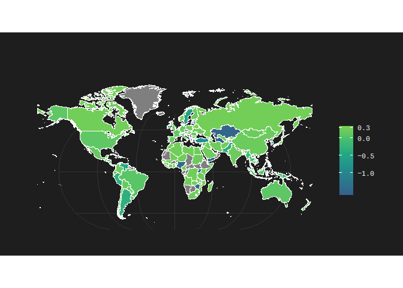

```r
# wciso <- rnaturalearthdata::countries50 %>%
#   as_tibble()

country_prrate<-country_profit_4year %>% group_by(country) %>%
  summarise(profit=sum(profit))%>%
  full_join(mutate(group_by(country_sales_4year,country),sales=sum(sales)))%>%
  mutate(prrate=profit/sales)

title=ggtitle(paste("全球利润率分布情况"))
country_prrate_png <- country_prrate%>% ggplot()+
  geom_sf(aes(fill=prrate,geometry=geometry),size=1,color="white") +
  theme_modern_rc(base_family = enfont,
                  caption_family = enfont,
                  subtitle_family = enfont,
                  )+
  coord_sf(crs = "+proj=eck4")+
  scale_fill_viridis_c(option = "viridis",name = "利润率",na.value="grey50",begin=0.3,end=0.8,breaks = c(-1,-0.5,0,0.3))+
  # scale_fill_gradient2(low="red",midpoint=0,mid="blue",high="green")+
    theme(strip.text = element_text(color = "white"),axis.text.x = element_blank())+
  title
ggsave("country_prrate.png", width = 12, height = 6, dpi = 1000)
country_prrate_png
```

### 2.6 不同地区的销售额sales情况静态图

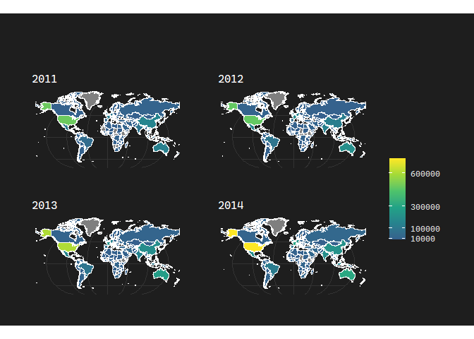

```r
theme_set(theme_bw())

title=ggtitle(paste("全球销售额年分布情况"))
country_sales_png <- country_sales_4year%>% ggplot()+

  geom_sf(aes(fill=sales,geometry=geometry),size=1,color="white") +
  theme_modern_rc(base_family = enfont,
                  caption_family = enfont,
                  subtitle_family = enfont,
                  )+
  coord_sf(crs = "+proj=eck4")+
  scale_fill_viridis_c(option = "viridis",name = "销售额",na.value="grey50",begin=0.3,end=1,breaks = c(10000,100000,300000,600000))+
    facet_wrap(~year,ncol=2)+
    theme(strip.text = element_text(color = "white"),axis.text.x = element_blank())+
  title
ggsave("country_sales_4years.png", width = 12, height = 6, dpi = 1000)
country_sales_png
```

### 2.7不同地区销售额2011至2014变化动图

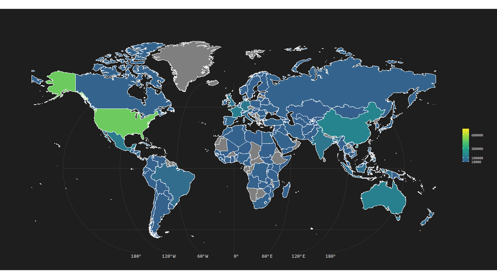

```r
country_sales_gif <- country_sales_4year%>% ggplot()+
  geom_sf(aes(fill=sales,geometry=geometry),size=1,color="white") +
   transition_manual(year) +
  labs(title = paste0("2011-2014销售额变化图")) +
  theme_modern_rc(base_family = enfont,
                  caption_family = enfont,
                  subtitle_family = enfont,
                  )+
  coord_sf(crs = "+proj=eck4")+
  scale_fill_viridis_c(option = "viridis",name = "销售额",na.value="grey50",begin=0.3,end=1,breaks = c(10000,100000,300000,600000))
anim_save("country_sales_4year.gif",animation = animate(country_sales_gif, height = 720, width = 1280))
animate(country_sales_gif, height = 720, width = 1280,fps=10,duration=8)
```

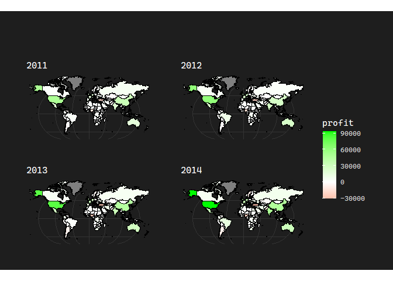

```r
title=ggtitle(paste("全球利润额年分布情况"))
country_profit_png <- country_profit_4year%>% ggplot()+
  geom_sf(aes(fill=profit,geometry=geometry),size=0.1,color="black") +
  theme_modern_rc(base_family = enfont,
                  caption_family = enfont,
                  subtitle_family = enfont,
                  )+
  coord_sf(crs = "+proj=eck4")+
  scale_fill_viridis_c(option = "viridis",name = "利润额",na.value="grey50",begin=0.3,end=1,breaks = c(-10000,0,10000,100000,300000,600000))+
  scale_fill_gradient2(low='red',midpoint=0,mid='white',high='green')+
    facet_wrap(~year,ncol=2)+
    theme(strip.text = element_text(color = "white"),axis.text.x = element_blank())+title
ggsave("country_profit_4years.png", width = 12, height = 6, dpi = 1000)
country_profit_png
```

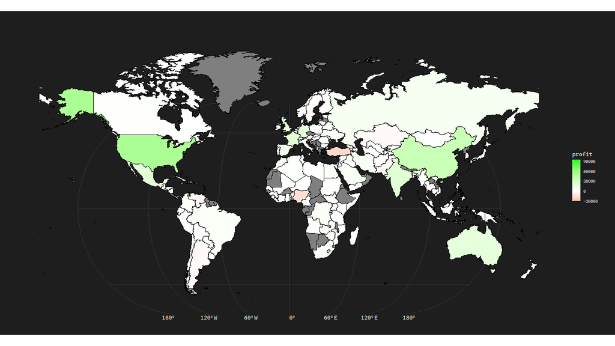

```r
country_profit_gif <- country_profit_4year%>%
  mutate(year=as.integer(year))%>%
  ggplot()+
  geom_sf(aes(fill=profit,geometry=geometry),size=0.1,color="black") +
   transition_manual(year) +
  labs(title = "{frame_year}:2011-2014利润额变化图") +
  theme_modern_rc(base_family = enfont,
                  caption_family = enfont,
                  subtitle_family = enfont,
                  )+
  coord_sf(crs = "+proj=eck4")+
  scale_fill_viridis_c(option = "viridis",name = "利润额",na.value="grey50",begin=0.3,end=1,breaks = c(-10000,0,10000,100000,300000,600000))+
  scale_fill_gradient2(low='red',midpoint=0,mid='white',high='green')

animate(country_profit_gif, height = 720, width = 1280,fps=10,duration=8)
```

```r
anim_save("country_profit_4year.gif",animation = animate(country_profit_gif, height = 720, width = 1280,start_pause = 3))
```

```r
#利润额前十的国家
country_profit_percent<-country_profit_total%>%
  na.omit(profit)%>%
  dplyr::filter(profit>0)%>%
  arrange(desc(profit))%>%
  mutate(profit_per=profit/sum(profit)*100)%>%
  select(c("country","profit_per"))
other_profit_per <- country_profit_percent %>% dplyr::filter(row_number()>9) %>%select(profit_per) %>%sum()
country_profit_percent<-country_profit_percent[0:9,]%>%
  rbind(c("其他",other_profit_per))%>%
  mutate(profit=as.double(profit_per))%>%
  arrange(profit)

country_profit_percent%>% hchart(type="pie",hcaes(x=country,y=profit))%>%
  hc_tooltip(pointFormat = '{series.name}: <b>{point.percentage:.1f}%</b>') %>%
  hc_title(text = '利润额前十的国家',
           style = list(fontFamily = "SourceHanSerifSC-Medium")) %>%
  hc_add_theme(hc_theme_flat()) %>%
  hc_plotOptions(pie = list(
    allowPointSelect = TRUE,
    cursor = 'pointer',
    dataLabels = list(
      enabled = T,
      format = '<b>{point.name}</b>: {point.percentage:.1f} %'
    ),
    showInLegend = T
  ))
```

[interactive chart not shown]

## 三、产品

### 3.1 三种类型产品在不同市场销售额分布雷达图

相对比较一致

```r
# products <- orders3%>%
#   select(c('country','type','sunbtype','sales','profit','quantity')) %>%
#   group_by
for(i in c(unique(orders$market))){assign(paste0("product_per_",i),orders %>%
  dplyr::filter(market == i) %>%
  group_by(type) %>%
  dplyr::summarise(totalsales = sum(sales))%>%
  mutate(sale_per=round(totalsales/sum(totalsales),2),market=i))}



highchart() %>%
  #polar设置极坐标
  hc_chart(polar = TRUE,type = "line") %>%
  hc_title(text = "各地区三种类型商品的销售额占比图",x=-60) %>%
  #设置图形大小
  hc_pane(size = "80%") %>%
  #设置图例位置
  hc_legend(align = "right",verticalAlign = "top",y = 70,layout = "vertical") %>%
  hc_xAxis(categories = c(unique(orders$type)),
           #横轴线宽设为0，隐藏横轴
           lineWidth = 0,
           #旋转图表分割线至多边形的顶点
           tickmarkPlacement = "on") %>%
  hc_yAxis(#设置图形为多边形
           gridLineInterpolation = "polygon",
           #纵轴线宽设为0，隐藏纵轴
           lineWidth = 0,
           min = 0) %>%
  hc_tooltip(#提示框同时显示两条线的同一个类别下的值
             shared = TRUE,
             #提示框格式
             pointFormat = '<span style="color:{series.color}">{series.name}: <b>{point.y}%</b><br/>')%>%
  hc_add_series(name="EMEA",data=product_per_EMEA$sale_per) %>%
  hc_add_series(name="亚太地区",data=product_per_亚太地区$sale_per) %>%
  hc_add_series(name="加拿大",data=product_per_加拿大$sale_per) %>%
  hc_add_series(name="拉丁美洲",data=product_per_拉丁美洲$sale_per) %>%
  hc_add_series(name="欧盟",data=product_per_欧盟$sale_per) %>%
  hc_add_series(name="美国",data=product_per_美国$sale_per) %>%
  hc_add_series(name="非洲",data=product_per_非洲$sale_per) %>%
  hc_add_theme(hc_theme_flat(chart = list(
    style = list(fontFamily = "Source Han Serif")
  ))) %>%
  hc_credits(enabled = T)
```

[interactive chart not shown]

### 3.2 三种类型产品在不同市场利润分布雷达图

```r
for(i in c(unique(orders$market))){assign(paste0("product_per_",i),orders %>%
  dplyr::filter(market == i) %>%
  group_by(type) %>%
  dplyr::summarise(totalprofit = sum(profit))%>%
  mutate(profit_per=round(totalprofit/sum(totalprofit),2),market=i))}


highchart() %>%
  #polar设置极坐标
  hc_chart(polar = TRUE,type = "line") %>%
  hc_title(text = "各地区三种类型商品的利润占比图",x=-60) %>%
  #设置图形大小
  hc_pane(size = "80%") %>%
  #设置图例位置
  hc_legend(align = "right",verticalAlign = "top",y = 70,layout = "vertical") %>%
  hc_xAxis(categories = c(unique(orders$type)),
           #横轴线宽设为0，隐藏横轴
           lineWidth = 0,
           #旋转图表分割线至多边形的顶点
           tickmarkPlacement = "on") %>%
  hc_yAxis(#设置图形为多边形
           gridLineInterpolation = "polygon",
           #纵轴线宽设为0，隐藏纵轴
           lineWidth = 0,
           min = 0) %>%
  hc_tooltip(#提示框同时显示两条线的同一个类别下的值
             shared = TRUE,
             #提示框格式
             pointFormat = '<span style="color:{series.color}">{series.name}: <b>{point.y}%</b><br/>')%>%
  hc_add_series(name="EMEA",data=product_per_EMEA$profit_per) %>%
  hc_add_series(name="亚太地区",data=product_per_亚太地区$profit_per) %>%
  hc_add_series(name="加拿大",data=product_per_加拿大$profit_per) %>%
  hc_add_series(name="拉丁美洲",data=product_per_拉丁美洲$profit_per) %>%
  hc_add_series(name="欧盟",data=product_per_欧盟$profit_per) %>%
  hc_add_series(name="美国",data=product_per_美国$profit_per) %>%
  hc_add_series(name="非洲",data=product_per_非洲$profit_per) %>%
  hc_add_theme(hc_theme_flat(chart = list(
    style = list(fontFamily = "Source Han Serif")
  ))) %>%
  hc_credits(enabled = T)
```

[interactive chart not shown]

### 3.3 三种产品的利润率

看得出来销售额和利润不一定成比例，所以我们研究一下利润率

基本一致，但加拿大的利润率高的吓人

```r
for(i in c(unique(orders$market))){assign(paste0("product_prrate_",i),orders %>%
  dplyr::filter(market == i) %>%
  group_by(type) %>%
  dplyr::summarise(totalprofit = sum(profit),totalsales = sum(sales))%>%
  mutate(prrate_per=round(totalprofit/totalsales,2),market=i))}

highchart() %>%
  #polar设置极坐标
  hc_chart(polar = TRUE,type = "line") %>%
  hc_title(text = "各地区三种类型商品的利润率图",x=-60) %>%
  #设置图形大小
  hc_pane(size = "80%") %>%
  #设置图例位置
  hc_legend(align = "right",verticalAlign = "top",y = 70,layout = "vertical") %>%
  hc_xAxis(categories = c(unique(orders$type)),
           #横轴线宽设为0，隐藏横轴
           lineWidth = 0,
           #旋转图表分割线至多边形的顶点
           tickmarkPlacement = "on") %>%
  hc_yAxis(#设置图形为多边形
           gridLineInterpolation = "polygon",
           #纵轴线宽设为0，隐藏纵轴
           lineWidth = 0,
           min = 0) %>%
  hc_tooltip(#提示框同时显示两条线的同一个类别下的值
             shared = TRUE,
             #提示框格式
             pointFormat = '<span style="color:{series.color}">{series.name}: <b>{point.y}%</b><br/>')%>%
  hc_add_series(name="EMEA",data=product_prrate_EMEA$prrate_per) %>%
  hc_add_series(name="亚太地区",data=product_prrate_亚太地区$prrate_per) %>%
  hc_add_series(name="加拿大",data=product_prrate_加拿大$prrate_per) %>%
  hc_add_series(name="拉丁美洲",data=product_prrate_拉丁美洲$prrate_per) %>%
  hc_add_series(name="欧盟",data=product_prrate_欧盟$prrate_per) %>%
  hc_add_series(name="美国",data=product_prrate_美国$prrate_per) %>%
  hc_add_series(name="非洲",data=product_prrate_非洲$prrate_per) %>%
  hc_add_theme(hc_theme_flat(chart = list(
    style = list(fontFamily = "Source Han Serif")
  ))) %>%
  hc_credits(enabled = T)
```

[interactive chart not shown]

### 3.4 subtype在不同market的占比情况

各种细分产品在不同市场销售分布雷达图

```r
for(i in c(unique(orders$market))){assign(paste0("product_per_",i),orders %>%
  dplyr::filter(market == i) %>%
  group_by(subtype) %>%
  dplyr::summarise(totalsales = sum(sales))%>%
  mutate(sale_per=round(totalsales/sum(totalsales),2),market=i))}

orders_AP<-orders %>% dplyr::filter(market == '亚太地区') %>%
  group_by(subtype) %>%
  dplyr::summarise(totalsales = sum(sales))

highchart() %>%
  #polar设置极坐标
  hc_chart(polar = TRUE,subtype = "line") %>%
  hc_title(text = "细分类型的商品的销售分布图",x=-60) %>%
  #设置图形大小
  hc_pane(size = "80%") %>%
  #设置图例位置
  hc_legend(align = "right",verticalAlign = "top",y = 70,layout = "vertical") %>%
  hc_xAxis(categories = c(unique(orders$subtype)),
           #横轴线宽设为0，隐藏横轴
           lineWidth = 0,
           #旋转图表分割线至多边形的顶点
           tickmarkPlacement = "on") %>%
  hc_yAxis(#设置图形为多边形
           gridLineInterpolation = "polygon",
           #纵轴线宽设为0，隐藏纵轴
           lineWidth = 0,
           min = 0) %>%
  hc_tooltip(#提示框同时显示两条线的同一个类别下的值
             shared = TRUE,
             #提示框格式
             pointFormat = '<span style="color:{series.color}">{series.name}: <b>{point.y}%</b><br/>')%>%
  hc_add_series(name="EMEA",data=product_per_EMEA$sale_per) %>%
  hc_add_series(name="亚太地区",data=product_per_亚太地区$sale_per) %>%
  hc_add_series(name="加拿大",data=product_per_加拿大$sale_per) %>%
  hc_add_series(name="拉丁美洲",data=product_per_拉丁美洲$sale_per) %>%
  hc_add_series(name="欧盟",data=product_per_欧盟$sale_per) %>%
  hc_add_series(name="美国",data=product_per_美国$sale_per) %>%
  hc_add_series(name="非洲",data=product_per_非洲$sale_per) %>%
  hc_add_theme(hc_theme_flat(chart = list(
    style = list(fontFamily = "Source Han Serif")
  ))) %>%
  hc_credits(enabled = T)
```

[interactive chart not shown]

### 各种产品的利润与销售额之比的分布

[figure not shown]

```r
sales <- orders %>%
  group_by(subtype) %>%
  dplyr::summarise(totalsales = sum(sales))
profit <- orders %>%
  group_by(subtype) %>%
  dplyr::summarise(totalprofit = sum(profit))
sale_profit<-cbind(sales,profit)
sale_profit<-sale_profit[,2:4]
sale_profit<-sale_profit%>%
  dplyr::mutate(rate=totalprofit/totalsales)
sale_profit$subtype = with(sale_profit,reorder(subtype,rate))

ggplot(sale_profit , mapping=aes(x = subtype, y = rate)) +
  geom_bar(stat='identity',fill="#1380A1") +
  labs(title="‘桌子’是唯一亏损的产品",
       subtitle = "所有类型产品利润与销售额的比率")+
  xlab('产品') + ylab('利润率')+
    geom_hline(yintercept = 0, size = 1, colour="#333333")
```

```r
ggsave('subtype_prrate.png')
```